# IODS course project

Meeri Seppä

# About the project

*This is a course about open data, open science and data science. I hope to learn more about how to use R and other tools for statistical analysis.*

**Click [here](https://github.com/Meeris/IODS-project) to access my github repository**

# Regression and Model Validation

## Introducing the Data

```r
library(dplyr)
lrn14 <- read.table("http://s3.amazonaws.com/assets.datacamp.com/production/course_2218/datasets/learning2014.txt ", sep=",", header=TRUE)
dim(lrn14)
```

```
## [1] 166   7
```

We are examinig a dataset that has information about students’ attitudes towards learning statistics. The dataset has 7 variables and 166 observations. We know the age, gender and how many points each students got in the exam. In addition, we we have divided the questions measuring student’s attitude toward learning into three subcategories: deep, strategic and surface learning. Each of these three variables illustrates the average of a student’s answers to questions in each category in a scale from 1 to 5. Click [here](http://www.helsinki.fi/~kvehkala/JYTmooc/JYTOPKYS3-meta.txt) to learn more about the variables.

## Overview of the Data

Now let us examine the data more in detail. From the graph below we can make following statements:

- We can see that we have nearly twice as much female students than male students. We can also see that the most of the students in our data are between 20 and 30 years old an that male students are on the average slightly older than female students.
- Male students have on the average a slightly better general attitude towards statistics than female students. The average attitude is 3.4 for male students and 3 for female students.
- Questions related to different types of learning have almost no difference between female and male students. The only exception being surface learning, where we can see a clearly smaller variance and higher mean among female students.
- The average amount of points in the final exam is 22.7. Male students were slightly better with an average of 23.5.

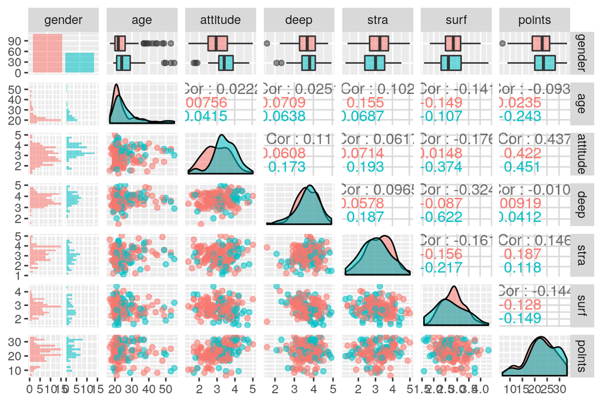

```r
library(ggplot2)
library(GGally)

ggpairs(lrn14, mapping = aes(col = gender, alpha = 0.3),
            lower = list(combo = wrap("facethist", bins = 20)))
```

## Fitting the Regression Model

We will build a regression model that has exam points as dependent variable. We will choose three variables correlated highly with points and use them as the explanatory variables in our model. The three most highly correlated variables are attitude, stra and surf.

The variable attitude is statistically significant with 0.1% confidence level. The other two variables are not statistically significant on their own. In order to find out whether a model with fewer variables would be better, we will have to carry out a F-test. So we will test the null hypothesis that the coefficients of the variables stra and surf are not statistically different from zero against hypothesis that either both or one of them is. The p-value of the F-statistics related to this question is 0.18 so we fail to reject the null hypothesis even with 10 percent confidence level. This means that a model with just the attitude variable as an explanatory variable would be more suitable.

```r
library(sandwich)
library(lmtest)
library(car)

model_1 <- lm(points ~ attitude + stra + surf, data = lrn14)
summary(model_1)
```

```
##
## Call:
## lm(formula = points ~ attitude + stra + surf, data = lrn14)
##
## Residuals:
##      Min       1Q   Median       3Q      Max
## -17.1550  -3.4346   0.5156   3.6401  10.8952
##
## Coefficients:
##             Estimate Std. Error t value Pr(>|t|)
## (Intercept)  11.0171     3.6837   2.991  0.00322 **
## attitude      3.3952     0.5741   5.913 1.93e-08 ***
## stra          0.8531     0.5416   1.575  0.11716
## surf         -0.5861     0.8014  -0.731  0.46563
## ---
## Signif. codes:  0 '***' 0.001 '**' 0.01 '*' 0.05 '.' 0.1 ' ' 1
##
## Residual standard error: 5.296 on 162 degrees of freedom
## Multiple R-squared:  0.2074, Adjusted R-squared:  0.1927
## F-statistic: 14.13 on 3 and 162 DF,  p-value: 3.156e-08
```

```r
linearHypothesis(model_1, c("surf = 0", "stra = 0"))
```

```
## Linear hypothesis test
##
## Hypothesis:
## surf = 0
## stra = 0
##
## Model 1: restricted model
## Model 2: points ~ attitude + stra + surf
##
##   Res.Df    RSS Df Sum of Sq      F Pr(>F)
## 1    164 4641.1
## 2    162 4544.4  2    96.743 1.7244 0.1815
```

## Model Interpretation

```r
model_2 <- lm(points ~ attitude, data = lrn14)
summary(model_2)
```

```
##
## Call:
## lm(formula = points ~ attitude, data = lrn14)
##
## Residuals:
##      Min       1Q   Median       3Q      Max
## -16.9763  -3.2119   0.4339   4.1534  10.6645
##
## Coefficients:
##             Estimate Std. Error t value Pr(>|t|)
## (Intercept)  11.6372     1.8303   6.358 1.95e-09 ***
## attitude      3.5255     0.5674   6.214 4.12e-09 ***
## ---
## Signif. codes:  0 '***' 0.001 '**' 0.01 '*' 0.05 '.' 0.1 ' ' 1
##
## Residual standard error: 5.32 on 164 degrees of freedom
## Multiple R-squared:  0.1906, Adjusted R-squared:  0.1856
## F-statistic: 38.61 on 1 and 164 DF,  p-value: 4.119e-09
```

Our fitted model is: points = 11.6 + 3.5*attitude

## Analysing the Diagnostic Plots

We can examine the normality assumption by examining the QQ-plot. We can see that our observations fit the line quite nice except at the start and end of the line. Based on this plot we can assume that the errors are normally distributed.

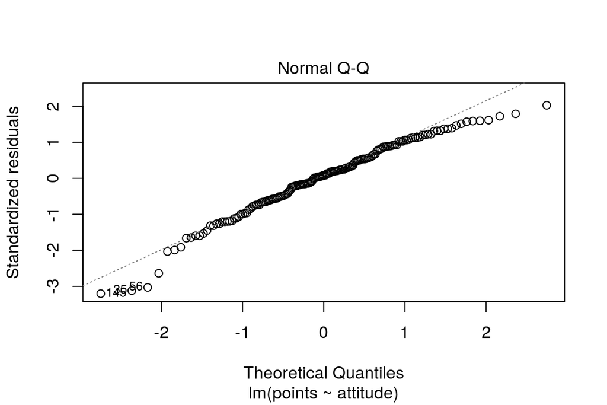

```r
plot(model_2, which= c(2))
```

Another assumption of the linear regression model is that the size of error does not depend on the value of the explanatory variables. We can see whether this assumption holds by examining the Residuals vs Fitted plot. We cannot find a clear pattern in the distribution of the errors so it is safe to state that this assumption holds.

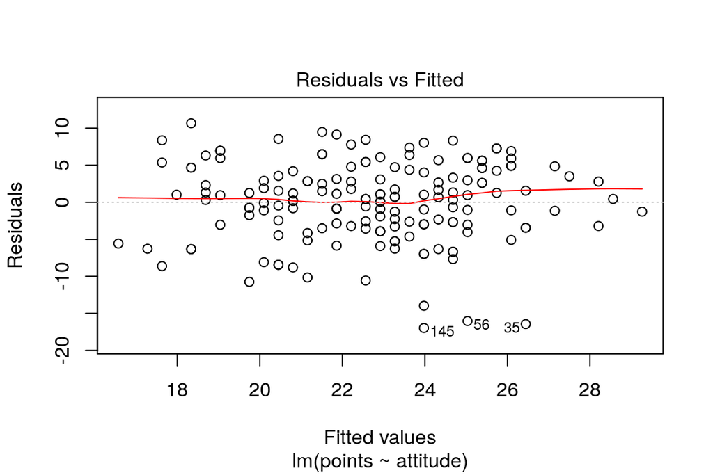

```r
plot(model_2, which= c(1))
```

The Residual vs Leverage plot allows us to study whether any observation has relatively higher leverage than others. We can easily see that there is no single observations that stands out.

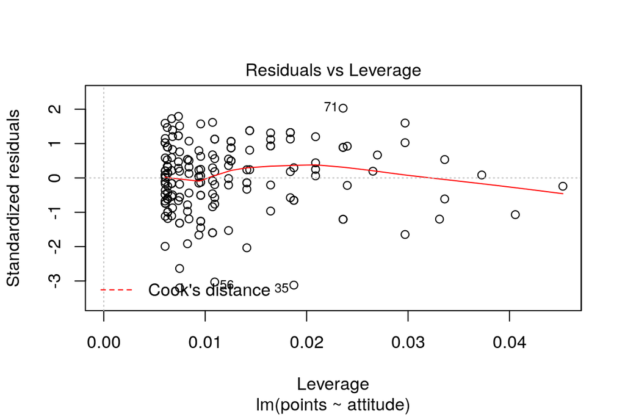

```r
plot(model_2, which= c(5))
```

# Logistic Regression

## Introducing the data

```
##  [1] "school"     "sex"        "age"        "address"    "famsize"
##  [6] "Pstatus"    "Medu"       "Fedu"       "Mjob"       "Fjob"
## [11] "reason"     "nursery"    "internet"   "guardian"   "traveltime"
## [16] "studytime"  "failures"   "schoolsup"  "famsup"     "paid"
## [21] "activities" "higher"     "romantic"   "famrel"     "freetime"
## [26] "goout"      "Dalc"       "Walc"       "health"     "absences"
## [31] "G1"         "G2"         "G3"         "alc_use"    "high_use"
```

The data what we are soon going to analyse is a about student alcohol consumption and school achievements. It is combined from two larger datasets about student achievement in two different courses (mathematics and Portugese language) in secondary education of two Portugese schools. In total, we have 382 observations and 35 variables. These variables consists of students spesific information such as age and sex, as well as information about his or hers family background and living habits. On top of this, we have the student’s grades in periods 1 to 3 (average of the two courses). We have also created two variables describing how much alcohol the student uses in total and whether he or she is a high user.

## Alcohol consumption and other variables

Let us explore the relationships between alcohol consumption and four other interesting variables.

| Variable | Prediction |
| --- | --- |
| Sex | Male students drink more tha female students and are more often high users |
| Failures | The number of failures is bigger if alcohol use is high |
| Absences | The number of absences is bigger if alcohol use is high |
| Romantic | Students who are in a romantic relationship drink less |

## Graphical overview

```
## # A tibble: 4 x 5
## # Groups:   high_use [?]
##   high_use sex   count mean_fail mean_abs
##   <lgl>    <fct> <int>     <dbl>    <dbl>
## 1 F        F       157     0.204     4.97
## 2 F        M       113     0.239     3.19
## 3 T        F        41     0.439     8.90
## 4 T        M        71     0.479     7.41
```

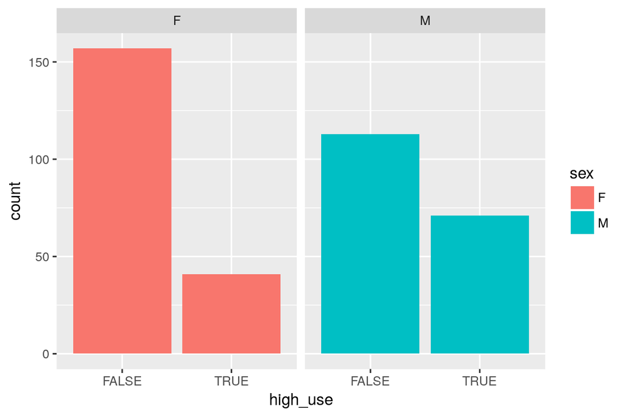

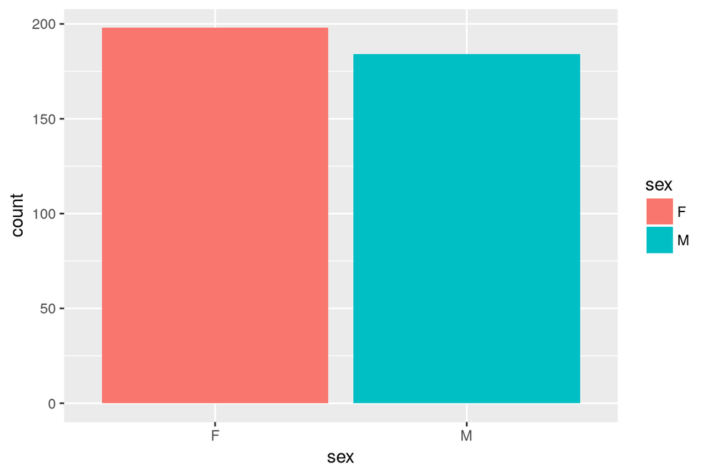

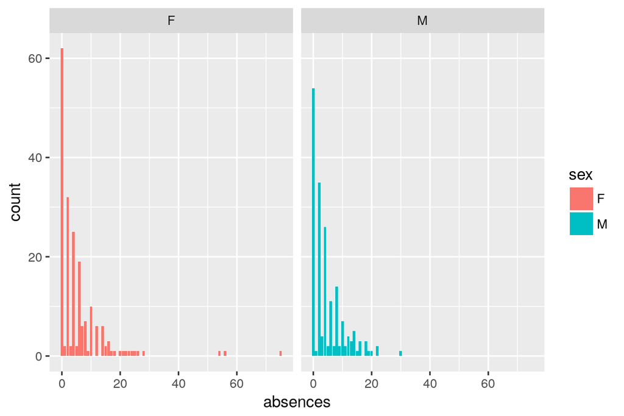

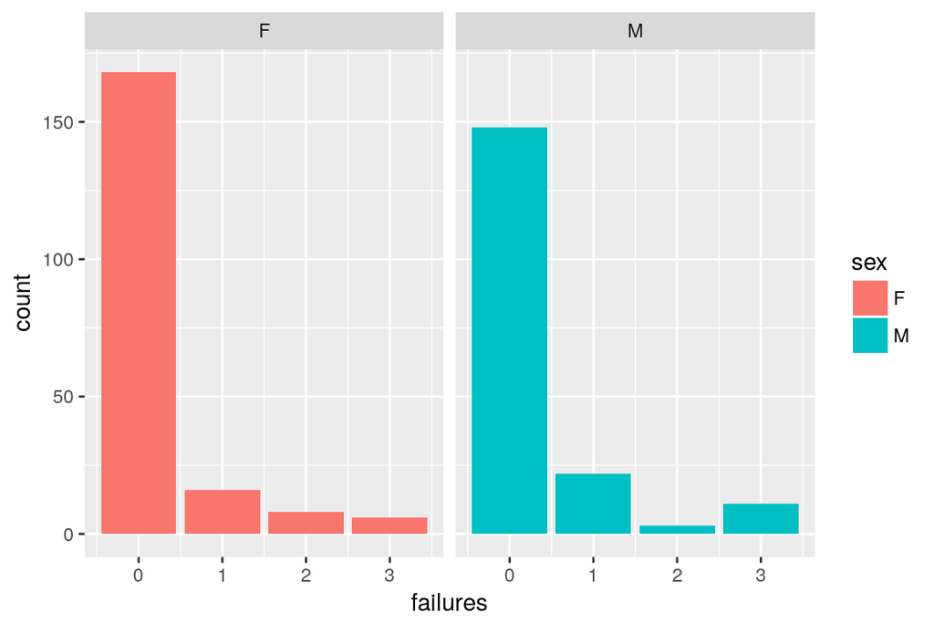

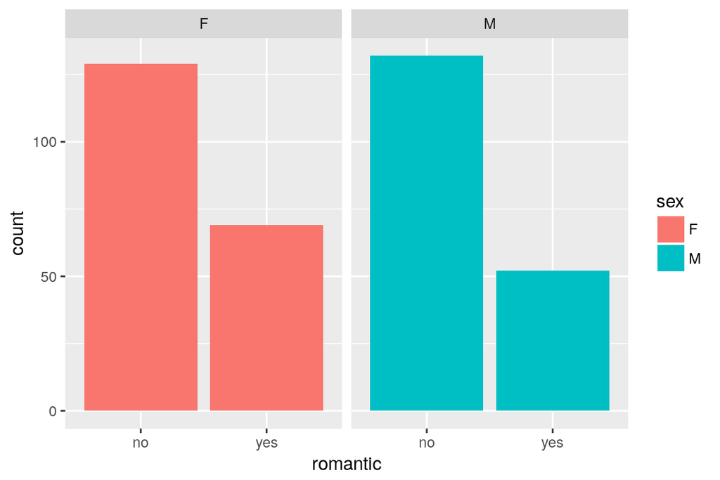

[figure not shown]

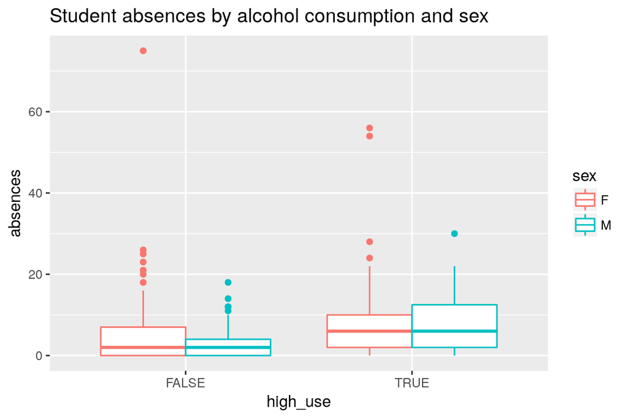

[figure not shown]

## The Model

Let us examine the summary of our fitted model:

```
##
## Call:
## glm(formula = high_use ~ failures + absences + sex + romantic,
##     family = "binomial", data = alc)
##
## Deviance Residuals:
##     Min       1Q   Median       3Q      Max
## -2.6507  -0.8256  -0.6131   1.0339   2.1292
##
## Coefficients:
##             Estimate Std. Error z value Pr(>|z|)
## (Intercept)  -1.8769     0.2381  -7.882 3.23e-15 ***
## failures      0.4142     0.1511   2.741  0.00613 **
## absences      0.0752     0.0182   4.132 3.59e-05 ***
## sexM          0.9757     0.2451   3.980 6.88e-05 ***
## romanticyes  -0.2806     0.2655  -1.057  0.29063
## ---
## Signif. codes:  0 '***' 0.001 '**' 0.01 '*' 0.05 '.' 0.1 ' ' 1
##
## (Dispersion parameter for binomial family taken to be 1)
##
##     Null deviance: 462.21  on 381  degrees of freedom
## Residual deviance: 417.51  on 377  degrees of freedom
## AIC: 427.51
##
## Number of Fisher Scoring iterations: 4
```

We can see that all but one of our coefficient are statistically different from zero. The coefficients of absences and gender are significant even with a confidence level of 0.1%. The coefficient of failures is significant with a 5% confidence level and the coefficient of romantic relationship is not significant even with a 10% level. This means that we could leave this variable from our model.

If we apply the exponent function to our model parameters, We can interpret them as odds ratios. The confidence interval tells us that the value of the coefficient is within these limits with 95% of the time.

```
##             odds_ratio 2.5 % 97.5 %
## (Intercept)       0.15  0.09   0.24
## failures          1.51  1.12   2.04
## absences          1.08  1.04   1.12
## sexM              2.65  1.65   4.32
## romanticyes       0.76  0.44   1.26
```

Now if we compare these results to our earlier predictions, we can see that they correspond eachother very nicely. Only deviation from our prediction is that the model suggests that the effect of romantic relationship might be ambigious.

## Testing the Predictive Power

The model we are going explore is the following. We dropped the variable *romantic* from our model as it was not statistically significant.

high_use ~ failures + absences + sex

```
##
## Call:
## glm(formula = high_use ~ failures + absences + sex, family = "binomial",
##     data = alc)
##
## Deviance Residuals:
##     Min       1Q   Median       3Q      Max
## -2.6629  -0.8545  -0.5894   1.0339   2.0428
##
## Coefficients:
##             Estimate Std. Error z value Pr(>|z|)
## (Intercept) -1.95397    0.22819  -8.563  < 2e-16 ***
## failures     0.40462    0.15024   2.693  0.00708 **
## absences     0.07294    0.01796   4.061 4.88e-05 ***
## sexM         0.98848    0.24453   4.042 5.29e-05 ***
## ---
## Signif. codes:  0 '***' 0.001 '**' 0.01 '*' 0.05 '.' 0.1 ' ' 1
##
## (Dispersion parameter for binomial family taken to be 1)
##
##     Null deviance: 462.21  on 381  degrees of freedom
## Residual deviance: 418.64  on 378  degrees of freedom
## AIC: 426.64
##
## Number of Fisher Scoring iterations: 4
```

Now we can test the predictive power of our model. As we can see from the table below, our model misclassified 12 non-high-users as high users and 86 high users to non-high-users. The model succeeded in predicting a high-users 26 times. The same results are displayed in the plot below labelled as “Actual values and the predictions”.

```
##         prediction
## high_use FALSE TRUE
##    FALSE   258   12
##    TRUE     86   26
```

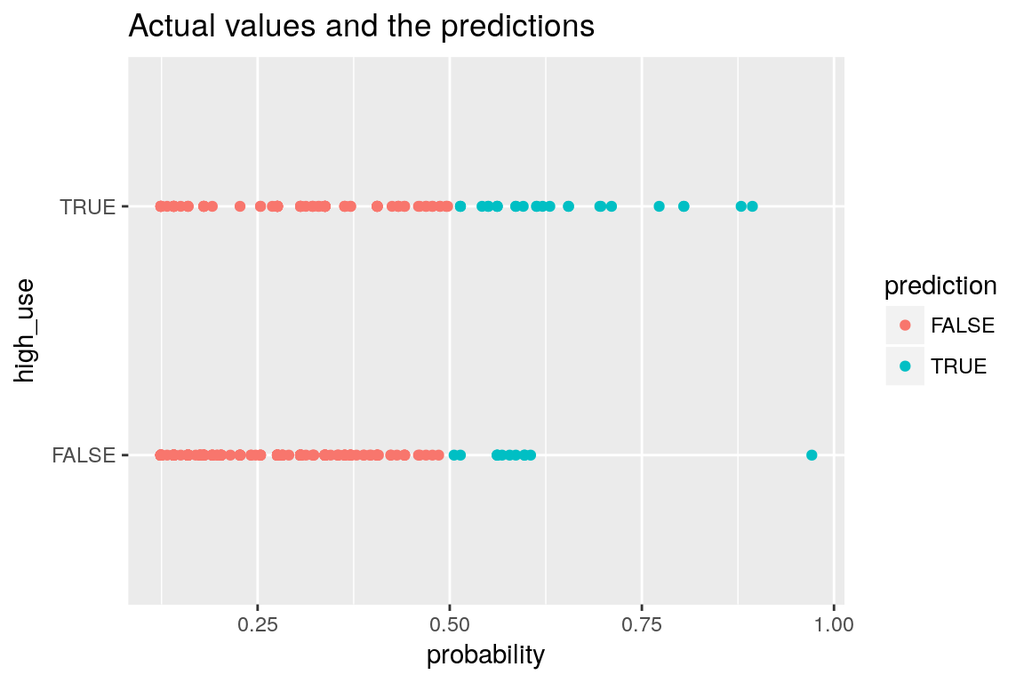

```
## [1] 0.2565445
```

Now we can compute the average number of wrong predictions by defining a loss function. In this case the number is 0.26 which is relatively low.

### Model Prediction vs. Guessing

We know that nearly on thrid of the students are high users of alcohol. No we can compare the performance of our model to a simple model that classifies every third person as a high user. Now we can see that the prediction error is nearly two times bigger. So at least our model is better at predicing high users than this simple guessing strategy.

```
## [1] 0.4319372
```

## Cross-Validation

```
## [1] 0.2617801
```

Now let us perform a 10-fold cross-validation on our model. The model has a test ser performance equal to the data Camp as the models have identical predictors. The prediction error is 0.2617801